# Latihan 3 MPDW - Distributed Lag Model & ARDL

# Latihan 2 : ARDL (Sales vs Advertising)

Diberikan data penjualan (Sales) dan biaya iklan (Advertising) tahunan dari 1975-2014. Akan dilakukan pemodelan **Autoregressive Distributed Lag (ARDL)** dan dicari model terbaik.

## Input Data

```r
Year <- 1975:2014
Sales <- c(11.7, 12.0, 12.3, 12.8, 13.1, 13.6, 13.9, 14.4, 14.7, 15.3,
           15.5, 15.8, 16.1, 16.6, 16.9, 16.7, 16.9, 17.4, 17.6, 17.9,
           18.0, 17.9, 18.0, 18.2, 18.2, 18.3, 18.6, 19.2, 19.3, 19.5,
           19.2, 19.3, 19.5, 20.0, 20.0, 19.9, 19.8, 19.9, 20.2, 21.0)
Advertising <- c(9.4, 9.6, 10.0, 10.4, 10.8, 10.9, 11.7, 12.2, 12.5, 12.9,
                  13.0, 13.2, 13.8, 14.2, 14.6, 14.9, 15.0, 15.4, 15.7, 15.9,
                  15.9, 16.0, 16.3, 16.2, 16.8, 17.3, 17.6, 18.1, 18.3, 18.5,
                  18.7, 18.9, 19.2, 20.0, 20.0, 20.3, 20.4, 21.0, 21.5, 22.1)

data2 <- data.frame(Year, Sales, Advertising)
data2
```

```
##    Year Sales Advertising
## 1  1975  11.7         9.4
## 2  1976  12.0         9.6
## 3  1977  12.3        10.0
## 4  1978  12.8        10.4
## 5  1979  13.1        10.8
## 6  1980  13.6        10.9
## 7  1981  13.9        11.7
## 8  1982  14.4        12.2
## 9  1983  14.7        12.5
## 10 1984  15.3        12.9
## 11 1985  15.5        13.0
## 12 1986  15.8        13.2
## 13 1987  16.1        13.8
## 14 1988  16.6        14.2
```

[output cut: 26 more lines]

## Eksplorasi Data

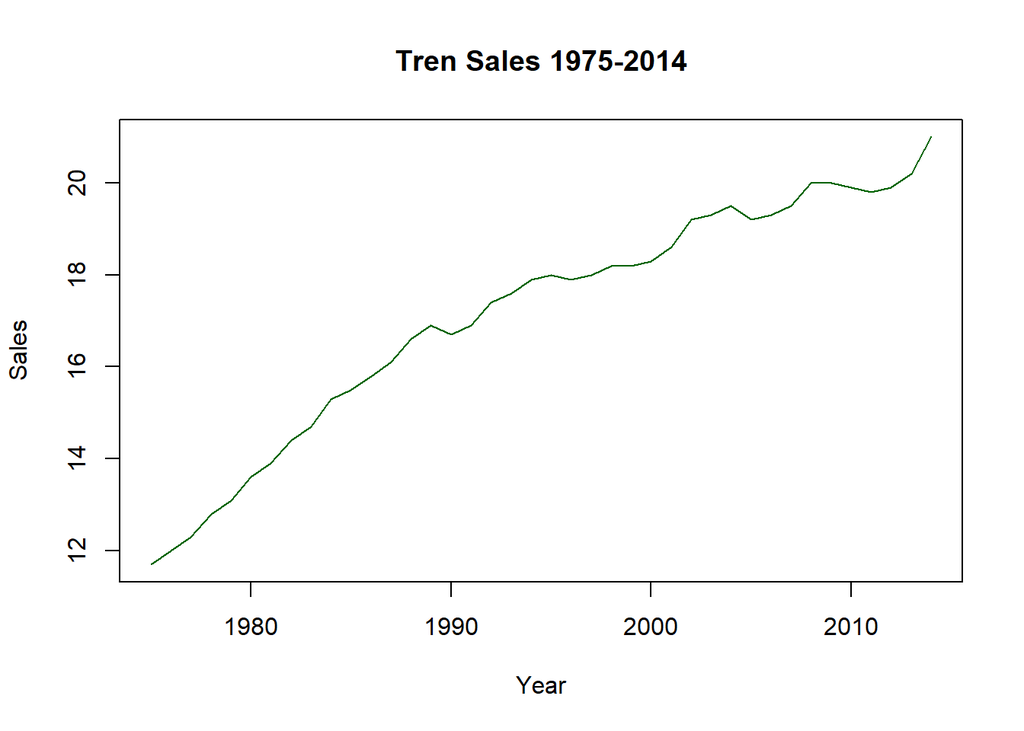

```r
plot(data2$Year, data2$Sales, type = "l", col = "darkgreen",
     xlab = "Year", ylab = "Sales", main = "Tren Sales 1975-2014")
```

## Pembagian Data

Data dibagi menjadi 32 tahun data training (1975-2006) dan 8 tahun data testing (2007-2014).

```r
data2_train <- data2[1:32, ]
data2_test  <- data2[33:40, ]
```

## Penentuan Lag Optimum ARDL

```r
model.ardl2.opt <- ardlBoundOrders(data = data.frame(data2), ic = "AIC",
                                    formula = Sales ~ Advertising)

min_p <- c()
for (i in 1:15) {
  min_p[i] <- min(model.ardl2.opt$Stat.table[[i]])
}
q_opt <- which(min_p == min(min_p, na.rm = TRUE))
p_opt <- which(model.ardl2.opt$Stat.table[[q_opt]] ==
                 min(model.ardl2.opt$Stat.table[[q_opt]], na.rm = TRUE))

data.frame("q_optimum" = q_opt, "p_optimum" = p_opt,
           "AIC" = model.ardl2.opt$min.Stat)
```

```
##   q_optimum p_optimum       AIC
## 1         3        14 -94.97914
```

> Catatan: jika `q_optimum` yang keluar = 0, `ardlDlm()` tidak bisa menerimanya (harus q >= 1). Dalam kasus itu, pakai kandidat terbaik berikutnya dari tabel `Stat.table` (q >= 1).